# InformeFinal

## **Hito 3 - Minería de Datos - CC5205**

**Grupo 4**

Integrantes:

- Antonia Arias
- Pía Antiquera
- Fernanda Contreras
- Paola López
- Belén Órdenes

Fecha de entrega: 17/07/2023

# **Introducción**

La educación superior en Chile ha ido aumentando su popularidad con el pasar de los años, hoy en día existe una gran parte de la población que se encuentra estudiando algunas de las carreras de la amplia gama que entregan las diversas entidades de educación, las cuales cuentan con variedad de programas y carreras técnicas y profesionales, y que tiene como objetivo formar profesionales y técnicos capaces de enfrentar los desafíos del mercado laboral. Actualmente en Chile hay alrededor de 27 universidades, 69 Institutos Profesionales y alrededor de 206 Centros de Formación Técnica reconocidos por el Estado en todo el país.

# **Motivación**

La educación ha sido por años un tema controversial en el país, por esto mismo es que ha estado sometido a diversos cambios a medida que pasa el tiempo, sin embargo, ¿es posible medir estos cambios?

La educación superior juega un papel fundamental en el desarrollo y crecimiento de un país. Al estudiar las tendencias y el comportamiento de la educación superior en Chile nos permitirá comprender mejor los desafíos y las oportunidades que enfrenta nuestro sistema de educación. A su vez el análisis de la base de datos de matriculados nos brindará información valiosa sobre las brechas educacionales existentes en el país. Se podrá analizar las desigualdades en el acceso a la educación superior entre diferentes regiones, géneros, edades y grupos socieconómicos, lo cuál podrá ser de ayuda para reducir estas brechas y poder promover una equidad educativa. Pero no es sólo el ingreso lo que se puede estudiar, sino también la calidad de la educación superior y la percepción que tiene los estudiantes de ella, se podrá analizar indicadores tales como la tasa de graduación, el rendimiento académico y la empleabilidad de los graduados, lo cual nos podrá permitir analizar el nivel de preparación de los estudiantes y la efectividad de las instituciones en la meta de formar profesionales competentes a lo que requiere la sociedad.

En resumen, al realizar un estudio de la educación superior en Chile, se podrá comprender de mejor forma el comportamiento del sistema educativo en el país, identificar brechas, evaluar la calidad, identificar tendencias de los estudiantes y contribuir al debate público sobre la educación. Logrando tener un impacto significativo en la mejora de la equidad y la calidad de la educación en Chile.

**Sobre el dataset escogido:**

- Base: [Matrículas históricas en educación superior en Chile](https://www.mifuturo.cl/bases-de-datos-de-matriculados/)
- Glosario variables: [Glosario bases de matrícula en educación superior](https://drive.google.com/file/d/1G9CGU1jhpSb5o8A5nc4NXmTz_IzTmFCL/view?usp=sharing)
- Fuente: Ministerio de Educación, específicamente del Servicio de Información de Educación Superior (SIES)
- Periodo de tiempo: 2007 - 2022
- Contenido: Registro de matrículas anuales por carrera, sede e institución.

**Preprocesamiento de la base de datos:**

- Selección de atributos de interés.
- Filtro del atributo “Años” para años desde 2010 a 2022 y “Nivel global” para nivel global de pregrado.
- Agrupación en el atributo “Tipo de institución” de Universidades privadas y Universidades privadas CRUCH en Universidades privadas.
- Eliminación de duplicados.
- Reemplazo de valores nulos a 0 cuando corresponde.

Los puntos anteriores fueron realizados usando la herramienta excel, se intentó hacer usando R o Python sin embargo estos códigos arrojaron error y no se pudo limpiar la base de esa forma, por lo que se optó por realizar directamente desde excel, primero se filtró el atributo "Años" para eliminar los datos desde 2007 a 2009 y sólo dejar los años 2010 a 2022 el cual será el período de estudio.

Fueron eliminadas las siguientes columnas para la realización del estudio:

- TOTAL MATRICULADOS
- TOTAL MATRICULADOS PRIMER AÑO
- CLASIFICACIÓN INSTITUCIÓN NIVEL 1
- CLASIFICACIÓN INSTITUCIÓN NIVEL 2
- NOMBRE SEDE
- ÁREA DEL CONOCIMIENTO
- CINE-F 1997 ÁREA
- CINE-F 1997 SUBAREA
- ÁREA CARRERA GENÉRICA
- NIVEL GLOBAL
- CARRERA CLASIFICACIÓN NIVEL 1
- CARRERA CLASIFICACIÓN NIVEL 2
- MODALIDAD
- TIPO DE PLAN DE LA CARRERA
- DURACIÓN ESTUDIO CARRERA
- CÓDIGO CARRERA
- TOTAL RANGO DE EDAD
- % COBERTURA TES
- CLAS_EST ADULTO
- CLAS_EST JOVEN

El reemplazo de valores nulos, también fue realizado directamente de excel, se seleccionaron los valores nulos y fueron cambiados por 0.

# **Exploración de Datos**

# **Hito 1**

Para el hito 1, se realizaron los siguientes análisis de datos:

**Gráfico 1: Instituciones por región**

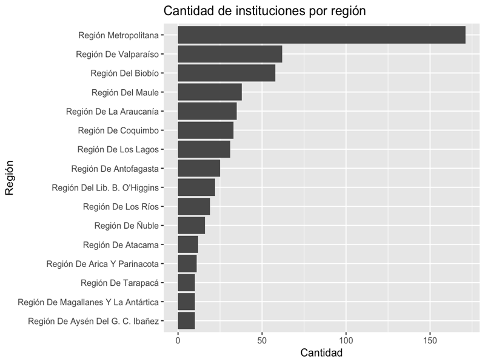

```python
from PIL import Image
from IPython.display import display

imagen = Image.open("/1.png")
nuevo_tamaño = (800, 600)
imagen_ajustada = imagen.resize(nuevo_tamaño)

display(imagen_ajustada)
```

Se observa que la Región Metropolitana es la que concentra la mayor cantidad de sedes del país, con 171 instituciones. Luego le sigue la Región De Valparaíso con 62 sedes. Por otra parte, la Región De Aysén Del G. C. Ibañez y Región De Tarapacá tienen solo 10 instituciones.

**Gráfico 2: Mujeres y hombres por área de carrera 2022**

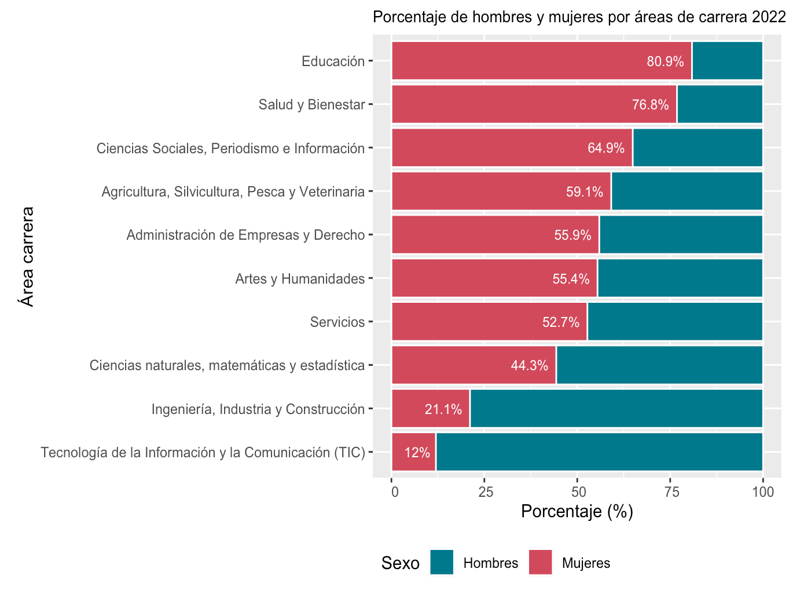

```python
imagen = Image.open("/3.png")
nuevo_tamaño = (800, 600)
imagen_ajustada = imagen.resize(nuevo_tamaño)

display(imagen_ajustada)
```

Se observa que Educación tiene más de un 80% de mujeres, luego le sigue Salud y Bienestar con 76,8%. Además, las áreas con menor porcentaje de mujeres son Ingeniería, Industria y Construcción con 21,1% de mujeres y Tecnología de la Información y la Comunicación con solo un 12%.

**Gráfico 3: Porcentaje de matriculados por área por región 2022**

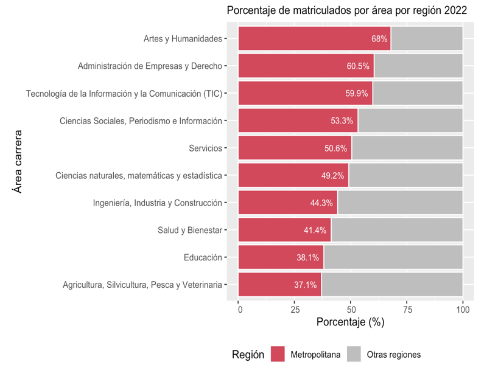

```python
imagen = Image.open("/4.png")
nuevo_tamaño = (800, 600)
imagen_ajustada = imagen.resize(nuevo_tamaño)

display(imagen_ajustada)
```

Se observa que Artes y Humanidades concentra la mayor cantidad de estudiantes en la Región Metropolitana con 68%. Por otro lado, Agricultura, Silvicultuta, Pesca y Veterinaria concentra el 62,9% de sus estudiantes en otras regiones, asi como Educación, con 61,9% también en otras regiones.

**Gráfico 4: Matrículas por rangos de edad**

Relacion entre rangos de edad y tipo de institucion

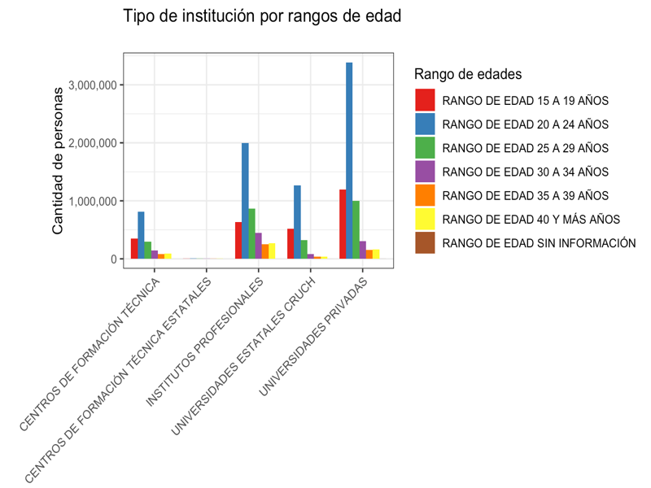

```python
imagen = Image.open("/5.png")
nuevo_tamaño = (800, 600)
imagen_ajustada = imagen.resize(nuevo_tamaño)

display(imagen_ajustada)
```

Este gráfico muestra la elección de tipos de institución por rangos de edad entre el año 2010 y 2022, mostramos la relación usando un gráfico de barras para cada rango de edad. Así, podemos observar la distribución, donde en el caso de las personas entre 25 y 29 años acceden mayoritariamente a universidades privadas, mientras que los mayores de 40 años tienen preferencia por institutos profesionales, y las personas entre 20 y 24 años tienen menor preferencia por centros de formación técnica.

**Gráfico 5: Relación entre rangos de edad y duración de carrera**

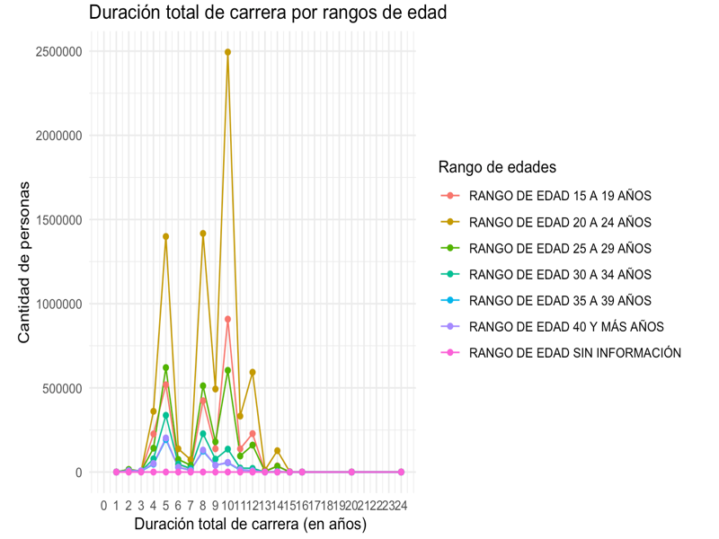

```python
imagen = Image.open("/6.png")
nuevo_tamaño = (800, 600)
imagen_ajustada = imagen.resize(nuevo_tamaño)

display(imagen_ajustada)
```

Dados los rangos de edad, se usó un gráfico de línea y dispersión para visualizar la duración total de la carrera entre 2010 y 2022, donde se observa que las personas entre 25 a 29 años tardan generalmente 5, 8 o 10 años en terminar su carrera y se observa también que la mayoría de personas entre 15 a 19 y 20 a 24, se demoran 10 años en terminar su carrera.

**Gráfico 6: Evolución del total de mujeres matriculadas por subárea**

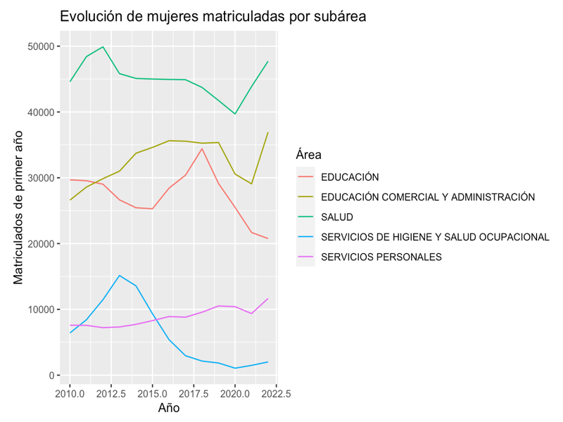

```python
imagen = Image.open("/7.png")
nuevo_tamaño = (800, 600)
imagen_ajustada = imagen.resize(nuevo_tamaño)

display(imagen_ajustada)
```

**Gráfico 7: Evolución del total de matriculados hombres por subárea**

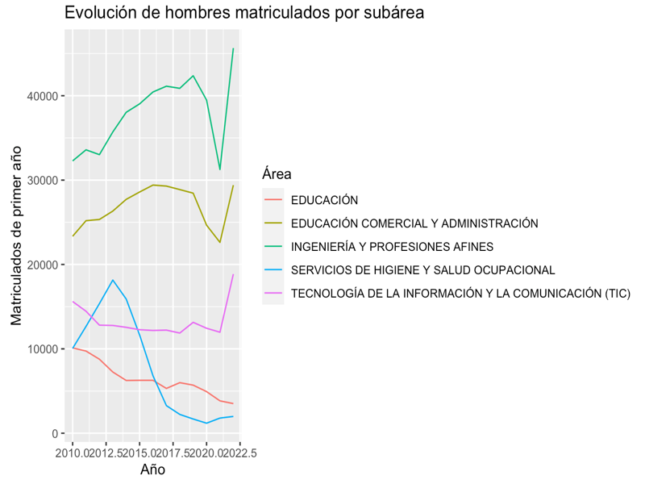

```python
imagen = Image.open("/8.png")
nuevo_tamaño = (800, 600)
imagen_ajustada = imagen.resize(nuevo_tamaño)

display(imagen_ajustada)
```

**Gráfico 8: Sueldos y duración de carrera**

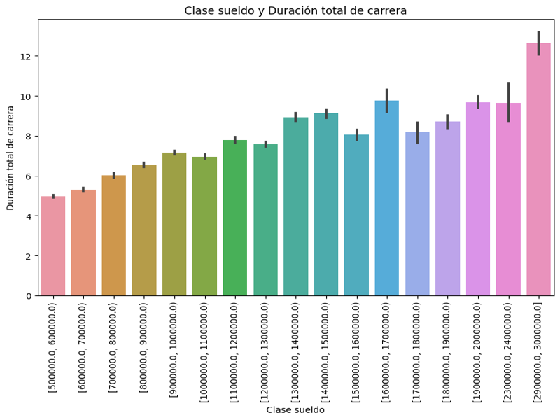

```python
imagen = Image.open("/graficonuevo.png")
nuevo_tamaño = (800, 600)
imagen_ajustada = imagen.resize(nuevo_tamaño)

display(imagen_ajustada)
```

# **Hito 2**

**Mejoras del hito 1:** Luego de realizar el análisis exploratorio para el hito anterior, nos percatamos que nuestras preguntas pueden ser respondidas con la base de datos sin mayor problema realizando un análisis estadístico simple, sin embargo para hacer más interesante el estudio es que hemos tomado la decisión de combinar la base de datos que estabamos usando con una [base de datos de empleabilidad e ingresos](https://www.mifuturo.cl/mi-futuro-buscadores/), la cual pertenece a la misma fuente de nuestra base principal, con esta combinación esperamos poder abordar más a profundidad el análisis sobre el comportamiendo en la educación superior en Chile, al combinar los datos tendremos acceso a más información que nos podrá ayudar a realizar conclusiones más relevantes en relación a la empleabilidad y los ingresos esperados por carrera. A su vez, hemos decidido modificar las preguntas que estudiaremos para que estas sean más generales y se incorporarán nuevas técnicas de minería de datos.

**Preprocesamiento de la nueva base de datos:** El cruce de las bases de datos presentó ciertos desafíos ya que la base de datos original utilizaba una llave compuesta por el tipo de institución y un nombre de carrera “variante” mientras que la base de datos complementaria utilizaba una llave compuesta por el tipo de institución y un nombre de carrera “genérico”. Dado lo anterior, la base de datos original tenía 1946 registros de nombres de carreras variantes y la base de datos complementaria tenía solo 245 registros de nombres de carreras genéricos. Para ejemplificar lo anterior, tenemos el caso del nombre de carrera genérico “Ingeniería logística” la cual presenta los siguientes nombres de carrera variantes; "Ingeniería logística", "Ingeniería en logística", "Ingeniería en gestión logística", "Ingeniería en gestión logística operativa", "Ingeniería en logística operativa", entre otros, todos estos hacen alusión a una misma carrera pero difieren en su nombre de acuerdo a la institución donde se imparte.

Dado este escenario, se llevó a cabo un cruce de datos utilizando un "inner join modificado" en base al nombre de carrera genérico y variante además de un "inner join normal" en base al tipo de institución. Este cruce se basó en "coincidir" cada nombre de carrera variante con el nombre de carrera genérico que tuviera la menor distancia según el criterio de Levenshtein y el tipo de institución como una coincidencia exacta.

Con lo anterior, se obtuvo una consolidación coherente con la base de datos original más 2 columnas nuevas obtenidas de la base de datos complementaria; empleabilidad e ingresos al 2º año de carrera.

[Algoritmo de cruce de bases de datos](https://colab.research.google.com/drive/16r-kOvaDj73vg0pF5V3S0s4YMOHMnj_r)

# **Exploración de Datos**

Primero se realizó un análisis exploratorio de datos para conocer los ingresos de los egresados, para esto se agregaron los datos de ingresos promedio al 2do (y 5to año de egreso), luego se crearon clases en base al mínimo y máximo valor de la columna de ingresos, con el fin de analizar el desbalance de las instancias de cada clase. Se realizó una exploración de los datos con el objetivo de encontrar resultados significativos. Se buscó identificar posibles relaciones entre los atributos y los ingresos de los egresados. Se encontró una relación en los atributos de la cantidad de estudiantes provenientes de distintos establecimientos educacionales(Municipal, Particular Subvencionado y Particular Pagado) y el tipo de enseñanza específico (Científico-Humanista y Técnico Profesional) para evaluar posibles disparidades en los ingresos.

Del análisis anterior se observó lo siguiente:

- Se observa un desbalance en los datos, se separó cada 100000 para hacer las clases, donde la clase con más instancias (23910) fue la de [900000.0, 1000000.0].

  Además los valores máximos y mínimos son 2941864 y 516072, respectivamente.
- Los colegios municipales tienen un nivel de ingresos en promedio más parejo en comparación con aquellos de colegios particulares pagados.
- Las personas que reciben una educación científico-humanista reciben sueldos de mayor ingreso en comparación con aquellos que reciben una educación técnico profesional.

Luego, se realizó un análisis para conocer la empleabilidad de las caarreras, para lo cual también se añadió el dato de empleabilidad al 2do año, luego se crearon las clases ['[0.2, 0.4)', '[0.4, 0.6)', '[0.6, 0.8)', '[0.8, 1.0]'] las cuales corresponden a la empleabilidad al 2do año y se prosiguió con el estudio, encontrando las siguientes observaciones:

- El promedio de la duración de carreras con empleabilidad en el rango [0.8, 1.0] es cercano a 8 y es aquel con duración más larga. Por otra parte, las carreras con empleabilidad en el rango de [0.2, 0.4) tienen la menor duración en promedio, cercano a 5 años. En general, se puede observar que a mayor rango, la duración promedio es también mayor.
- La clase de empleabilidad [0.8, 1.0] es en el que predominan las carreras impartidas en Universidades. En el resto de las clases hay mayor cantidad de carreras impartidas en Institutos Profesionales (IP) y estas se concentran en la clase [0.6, 0.8). Finalmente, los Centros de Formación Técnica (CFT) no predominan en ninguna clase, pero la mayor cantidad se concentra en la clase [0.6, 0.8).
- La mayor cantidad de matriculados en carreras en la clase [0.6, 0.8) son mujeres, lo mismo ocurre para [0.2, 0.4) y [0.4, 0.6). En cambio, en la clase [0.8, 1.0] se observa que predominan la cantidad de hombres.

Para revisar el código, los gráficos generados de donde se encontraron las observaciones anteriores y más análisis sobre sueldo y empleabilidad, ingresar al siguiente [link](https://colab.research.google.com/drive/1D3K7qomuljeMNfy7M-bfl1WbmWAuDW17#scrollTo=Et-CWqqGVJDA).

# **Preguntas y problemas**

Una de las mejoras realizadas respecto al hito 1 tiene que ver con las preguntas planteadas, como dijimos con anterioridad, nuestras preguntas anteriores podían ser respondidas con un análisis estadístico simple, por lo que hemos decidido replantear estas preguntas para utilizar otras técnicas de minería de datos y así lograr un estudio más interesante sobre el comportamiento de la educación superior en el país, por lo que hemos formulado las siguientes preguntas:

1. ¿Es posible conocer los ingresos al segundo año de los egresados de una carrera en base a los atributos conocidos de esta?
2. ¿Es posible conocer el nivel de empleabilidad al segundo año de egreso de una carrera en base a los atributos conocidos de esta?
3. ¿Es posible predecir las brechas de género en las carreras con determinada exactitud en base a los atributos de esta?

# **Propuesta experimental**

Para responder las **preguntas 1 y 2**, se realizó el siguiente preprocesamiento:

1. Fueron borrados las columnas TES para un mejor rendimiendo del modelo.
2. Se eliminaron las siguientes columnas: nombre de carrera, código de institución, nombre genérico de carrera, código de institución, promedio edad carrera, promedio edad mujeres, promedio edad hombres. Se eliminó provincia y comuna dejando únicamente región, puesto que con la región basta para contextualizar al alumnado. A su vez fueron eliminadas las columnas matriculados mujeres primer año y matriculados hombres primer año, puesto que basta con los matriculados totales de cada genero para poder realizar nuestro estudio.
3. Las tres columnas de área y sub-áreas de la carrera fueron dejadas intactas.
4. Para optimizar el modelo fueron normalizados todas las columnas que tuvieran una cantidad de personas, las cuales fueron especificamente matriculados hombres por programa, matriculados mujeres por programa, rango, tipo dee establecimiento HC y tipo establecimiento TP.
5. Se mantuvieron las columnas de acreditación y jornada.
6. Se binarizó la duración de carrera de la siguiente forma:
   - Si es mayor a 5, el resultado será 1
   - Si es menor a 5, el resultado será 0
7. Se implementó un modelo de clasificación con distintos algoritmos obteniendo métricas de interés tales como precisión promedio, recall promedio y f1-score promedio.

Para la realización de las preguntas 1 y 2 se tomó una muestra del 50% de los datos, dado que nuestra cantidad de datos es del orden de miles, al ejecutar el código no lograba ejecutarse completamente sin ocasionar problemas computacionales, se escogió ese porcentaje dado que consideramos es una muestra representativa para el estudio que se quiere realizar.

Para responder la **pregunta 3** se realizó el siguiente preprocesamiento:

1. Utilización de la BD la cual mantuvo sólo las columnas de interés desde el 2010 al 2022 además de una nueva columna definida como "Brecha" calculada a partir de la cantidad de hombres y cantidad de mujeres matriculada en la carrera en un año e institución específica.
2. Se convierten las variables categóricas en variables dummy mediante la función "get_dummies". Esto implica crear columnas binarias para cada categoría única en las columnas seleccionadas.
3. Dado el aumento de dimensionalidad inherente provocada por la conversión a variables dummys se aplico la técnica de PCA para reducir la dimensionalidad a 10 componentes principales en base al criterio de variación acumulativa.
4. Se particiona el conjunto de instancias disponibles en entrenamiento, validación y testeo.
5. Se implementó un modelo de regresión lineal obteniendo métricas de interés tales como error cuadrático medio (MSE), raíz del error cuadrático medio (RMSE), coeficiente de determinación (R^2) y error absoluto medio (MAE).

Para revisar los códigos y resultados revisar los siguientes links, debido a que el tiempo que se demoran en correr los códigos es bastante (lo cual se explicará a mayor detalle en la sección de "Resultado Preliminar") no se recomienda correr el código directamente en el google colab puesto que la memoria RAM propia de esta herramienta no es suficiente para la ejecución del programa, por lo cual si se desea correr el código es recomendable descar el archivo .ipynb y abrirlo usando las aplicaciones VSCode o Jupyter notebook.

[Pregunta 1](https:///colab.research.google.com/drive/1xZUj0BeXFGgPRg5WtgnRQpI0UE2nPFwR)

[Pregunta 2](https://colab.research.google.com/drive/1lYFQckXxvSpi_KDeVi2FsHlKykofyLy3)

[Pregunta 3](https://colab.research.google.com/drive/10NylOke_Dvh6cyXKGqr-WVGk48edUsXX?usp=sharing)

# **Resultado Preliminar**

Se aplicó la técnica de clasificación para responder la pregunta *¿Es posible conocer el nivel de empleabilidad al segundo año de egreso de una carrera en base a los atributos conocidos de la carrera?*, usando el preprocesamiento explicado para la pregunta 1 en el apartado anterior, lo cual arrojó los siguientes resultados:

```python
import pandas as pd
from tabulate import tabulate


data = {'Métrica/Algoritmo': ['Precisión promedio', 'Recall promedio', 'F1-score promedio'],
        'KNN (225 m 35.3s)': [0.77, 0.77, 0.76],
        'Decision tree (14 m 47.8s)': [0.66, 0.65, 0.64],
        'Gaussian Naive Bayes (17 m 17.2s)': [0.48, 0.19, 0.14],
        'Base Dummy (3 m 6.7s)': [0.37, 0.37, 0.37]}
df = pd.DataFrame(data)

tabla = tabulate(df, headers='keys', tablefmt='psql')
print(tabla)
```

```
+----+---------------------+---------------------+------------------------------+-------------------------------------+-------------------------+
|    | Métrica/Algoritmo   |   KNN (225 m 35.3s) |   Decision tree (14 m 47.8s) |   Gaussian Naive Bayes (17 m 17.2s) |   Base Dummy (3 m 6.7s) |
|----+---------------------+---------------------+------------------------------+-------------------------------------+-------------------------|
|  0 | Precisión promedio  |                0.77 |                         0.66 |                                0.48 |                    0.37 |
|  1 | Recall promedio     |                0.77 |                         0.65 |                                0.19 |                    0.37 |
|  2 | F1-score promedio   |                0.76 |                         0.64 |                                0.14 |                    0.37 |
+----+---------------------+---------------------+------------------------------+-------------------------------------+-------------------------+
```

De los resultados anteriores se puede apreciar que el KNN fue de los clasificadores con mejor rendimiento pues obtuvo valores relativamente buenos en comparación con los demás clasificadores, siendo uno de los más efectivos. Por contra parte el Gaussian Naive Bayes fue el que obtuvo los peores resultados de rendimiento.

En cuanto a los tiempos de ejecución el KNN demoró casi 4 horas en arrojar resultados mientras que el que tuvo menor tiempo de ejecución fue el de Base Dummy.

Podemos concluir que nuestra pregunta si puede ser respondida puesto que el clasificador KNN arrojó valores cercanos a 0.77 en cada una de sus métricas lo cual lo convierte en un clasificador bastante fiable, como el valor es cercano a 1 la precisión es elevada y viable, en segundo lugar el calificador de Decision tree también arrojó valores bastantes positivos para nosotras, con valores cercanos a 0.66 en cada una de sus métricas lo cual indica un precisión mayor al 50%. Por otra parte los clasificadores Gaussian Naive Bayes y Base Dummy fueron los que arrojaron valores muy inferiores lo cual hace inviable responder la pregunta utilizando estas métricas pues su precisión es mucho menor al 50%.

Sin embargo, el tiempo de ejecución de KNN es bastante elevado para realizar el estudio, si bien es el más viable y fiable de las 4 métricas, su tiempo de ejecución es muy alto, por lo tanto una de las tareas para el próximo hito será el buscar una forma de volver más eficiente la ejecución de este código. Además por esfuerzo computacional aún no se ha podido ejecutar el código que da a ese arbol con las variables de cada nodo, por lo que también otra de nuestras tareas será encontrar esta solución para revisar dichas variables.

A partir de lo anterior, si bien se obtuvieron resultados que parecieran respaldar la respuesta afirmativa a la pregunta planteada, es importante tener en cuenta la posibilidad de que en los resultados obtenidos existan sesgos potenciales dados diversos motivos, entre los principales:

- **Sesgo por selección de variables:** Durante el preprocesamiento se seleccionaron variables de interés para el modelo, si esta selección de variables no es representativa de la totalidad de la información relevante para el problema el modelo puede sesgarse al no considerar características importantes.
- **Sesgo por omisión de variables:** Existe la posibilidad de que las bases de datos implementadas no presentaran algun atributo relevante para el modelo o que este no haya sido parte de la selección de variable por lo que el modelo puede sesgarse por una falta de consideración de factores relevantes y una visión incompleta del problema lo que afecta la calidad de las predicciones.
- **Sesgo por utilización de muestra aleatoria de la base de datos:** Dada la capacidad computacional requerida para aplicar el modelo en todo el conjunto de datos se implementó el modelo solo en una muestra de este la cual puede no ser representativa de la totalidad de la base de datos. Si existe una distribución desigual de clases o características en la base de datos completa y la muestra aleatoria no refleja esta distribución, el modelo puede sesgarse hacia la información contenida en la muestra y no generalizar correctamente a nuevos datos.

Como se mencionó con anterioridad el código con los resultados se encuentra en el link de la pregunta 1 del apartado anterior ("Propuesta experimental").

# **Hito 3**

**Mejoras del hito 2:** Dado que al termino del hito anterior nos dimos cuenta de los posibles sesgos que podrían causar nuestras decisiones sobre las variables de la base de datos se realizó un análisis más austero sobre ello. En esta ocasión se decidió excluir los rangos de edades y se realizó un sample completo, gracias a lo anterior los tiempos de ejecución de los modelos tuvieron una considerable disminución. Sobre las columnas TES, nos percatamos que la única relevante es la columna TES total, sin embargo, este es simplemente un indicador del número de matriculados y no aporta mayor información en el análisis. También se realizó un PCA llegando a la conclusión de que no aportaría mucho en el estudio puesto que existe una gran cantidad de solapamiento en los datos. Sobre los datos nulos que fueron reemplazados por valor cero, esto se realizó dado que la las filas en donde se encuentran los nulos son valores numéricos y dado que no se puede realizar de buena forma el análisis exploratorio de datos teniendo estos atributos como nulos, es que se decidió cambiarlos a cero, este cambio no generó influencia en el análisis puestos que los valores cambiados a cero eran consistentes con el contexto de la base de datos (por ejemplo si en una columna se estaban analizando los datos de mujeres matriculadas y esta característica aparecía como nulo significaba que no había existencia de mujeres matriculadas en esa carrera, por lo tanto era completamente consistente dejar la variable como cero).

# **Resultado final**

### **PREGUNTA 1 y 2**

> **Pre-procesamiento**

Se realizó el mismo preprocesamiento mencionado en el hito anterior para las preguntas 1 y 2, sin embargo se realizaron ciertos cambios que se detallaran a continuación,

1. Fueron borrados las columnas TES para un mejor rendimiendo del modelo.
2. Se eliminaron las siguientes columnas: nombre de carrera, código de institución, nombre genérico de carrera, código de institución, promedio edad carrera, promedio edad mujeres, promedio edad hombres. Se eliminó provincia y comuna dejando únicamente región, puesto que con la región basta para contextualizar al alumnado. A su vez fueron eliminadas las columnas matriculados mujeres primer año y matriculados hombres primer año, puesto que basta con los matriculados totales de cada genero para poder realizar nuestro estudio.
3. Las tres columnas de área y sub-áreas de la carrera fueron dejadas intactas.
4. Para optimizar el modelo fueron normalizados todas las columnas que tuvieran una cantidad de personas, las cuales fueron especificamente matriculados hombres por programa, matriculados mujeres por programa, rango, tipo dee establecimiento HC y tipo establecimiento TP.
5. Se mantuvieron las columnas de acreditación y jornada.
6. Se binarizó la duración de carrera de la siguiente forma:
   - Si es mayor a 5, el resultado será 1
   - Si es menor a 5, el resultado será 0
7. Se implementó un modelo de clasificación con distintos algoritmos obteniendo métricas de interés tales como precisión promedio, recall promedio y f1-score promedio.
8. Los atributos que fueron considerados **importantes** fueron: el tipo de establecimmiento (humanista científico), el número de matriculados de cada género, la duración de la carrera y el código de institución. Siendo los atributos de enfoque del estudio dado que son los que se encuentran más relacionados con la empleabilidad y el ingreso, el cual era el enfoque de nuestras preguntas.
9. Los atributos considerados **irrelevantes** fueron: los matriculados según el rango de edad y los TES (municipal, particular, etc.) puesto que son las menos correlacionadas con ingreso y empleabilidad.

Las correlaciones mencionadas anteriormente se pueden observar en la matriz de correlación realizada en el AED, el cual puede revisar en el siguiente [link](https://colab.research.google.com/drive/1oA8YQ-Ty1W1dgyTMRh8aR18vYyUH7x8c).

Para revisar los códigos y resultados revisar los siguientes links:

[Pregunta 1](https://drive.google.com/file/d/1Vlgm9hU_1Gvj4SzOdX6BKZm8xQIabpC8/view?usp=drive_link)

[Pregunta 2](https://drive.google.com/file/d/1gK15GSQfc639b6VZUcSzldJwTinWDYTQ/view?usp=drive_link)

[Pregunta 1 "sin ayuda"](https://drive.google.com/file/d/1dVJeD1stR6trMDD9uYUdvmwq45Fy90hp/view?usp=drive_link)

[Pregunta 2 "sin ayuda"](https://drive.google.com/file/d/17D_9eHYV72qBTKHzbDiuRjwUiTNL1HC-/view?usp=drive_link)

La diferencia entre los códigos "sin ayuda" y los normales recae en que los códigos "con ayuda" corren utilizando la otra columna nueva que se está estudiando, en el caso de la pregunta referente a empleabilidad, este código correría haciendo uso de la columna de ingreso, caso análogo para la pregunta referente a ingresos, es una ayuda puesto que el código se ejecuta utilizando estos datos que son justamente los que queremos estudiar. Por otro lado, los códigos "sin ayuda" no hacen uso de estas columnas para el estudio.

Además se realizó el siguiente [PCA](https://drive.google.com/file/d/1HKr0vWQQYEDF1eqTxxVUPQ_X5jmJc29M/view?usp=drive_link) con el fin de reducir la dimensionalidad de los datos, encontrando combinaciones lineales de variables originales que capturen la mayor varianza de los datos, sin embargo, esta herramienta no fue de mucha ayuda debido al solapamiento que existe entre los datos.

> **Propuesta experimental**

Para responder las preguntas 1 y 2 utilizan varios algoritmos de clasificación, esto para evaluar su rendimiento sin sesgos por clasificadores no adecuados, dado que cada uno tiene fortalezas y debilidades, y rinden de manera distinta dependiendo del data. Se considera que un f1-score de 0.6 es el umbral, a partir del cual la clasificación es exitosa. Los clasificadores que se evaluaron son:

- **K-Nearest Neighbors (KNN)**: KNN utiliza para clasificar un punto de datos según la mayoría de las etiquetas de sus k vecinos más cercanos en el espacio de características. La predicción se realiza asignando la clase más común entre los vecinos más cercanos. Puede ser computacionalmente costoso en conjuntos de datos grandes y puede verse afectado negativamente por características irrelevantes o ruido en los datos.
- **Base Dummy**: El clasificador Dummy es un enfoque básico de clasificación que se utiliza como referencia para evaluar el rendimiento de otros modelos más sofisticados. Básicamente, este clasificador realiza predicciones de manera aleatoria o siguiendo una regla simple. No se basa en ninguna relación entre las características y las etiquetas. Su fortaleza radica en proporcionar una línea de base para comparar otros modelos y detectar si un modelo más complejo está realmente aprendiendo patrones significativos en los datos.
- **Árbol de Decisión**: El árbol se construye dividiendo repetidamente el conjunto de datos en función de la característica que mejor separa las clases. Las fortalezas del árbol de decisión incluyen la facilidad de interpretación, la capacidad de manejar datos numéricos y categóricos, y la generación automática de reglas de decisión. Sin embargo, pueden ser propensos al sobreajuste si no se controla su crecimiento adecuadamente.
- **Gaussian Naive Bayes**: El clasificador Naive Bayes es un método probabilístico basado en el teorema de Bayes con la suposición de independencia condicional entre las características. El enfoque gaussiano es una variante que asume que los datos siguen una distribución normal (gaussiana). Es especialmente útil cuando se trabaja con conjuntos de datos pequeños y su fuerza radica en su eficiencia computacional y su capacidad para trabajar bien incluso con un número limitado de datos de entrenamiento. Sin embargo, la suposición de independencia condicional puede no ser válida en todos los conjuntos de datos y, por lo tanto, puede no funcionar óptimamente en situaciones más complejas.
- **Support Vector Machine (SVM)**: SVM es un poderoso algoritmo de aprendizaje supervisado que se utiliza tanto para clasificación como para regresión. Su objetivo principal en la clasificación es encontrar el hiperplano que mejor separa las clases en el espacio de características. La fuerza de SVM radica en su capacidad para manejar eficientemente espacios de características de alta dimensión y en su habilidad para identificar fronteras de decisión no lineales utilizando trucos del kernel. SVM también es resistente al sobreajuste y puede manejar eficazmente conjuntos de datos con margen de separación entre clases. Sin embargo, puede ser más complicado de configurar y computacionalmente costoso en grandes conjuntos de datos.

Además de evaluar las métricas de rendimiento, es importante tener en mente los tiempos de ejecusión.

1. **¿Es posible conocer el nivel de empleabilidad al segundo año de egreso de una carrera en base a los atributos conocidos de esta?**

> **Resultados**

```python
data = {'F1-score/tiempo': ['Incluyendo ingreso', 'Sin incluir ingreso'],
        'Support vector machine': ['0.9 / 106m', '0.77 / 89m'],
        'KNN': ['0.81 / 3m 35s', '0.71 / 2m 42s'],
        'Decision tree': ['0.64 / 1m 22s', '0.6 / 1m 21s'],
        'Gaussian Naive Bayes': ['0.95 / 59s', '0.8 / 57s'],
        'Base Dummy': ['0.39 / 13s', '0.39 / 17s']}
df = pd.DataFrame(data)

tabla = tabulate(df, headers='keys', tablefmt='psql')
print(tabla)
```

```
+----+---------------------+--------------------------+---------------+-----------------+------------------------+--------------+
|    | F1-score/tiempo     | Support vector machine   | KNN           | Decision tree   | Gaussian Naive Bayes   | Base Dummy   |
|----+---------------------+--------------------------+---------------+-----------------+------------------------+--------------|
|  0 | Incluyendo ingreso  | 0.9 / 106m               | 0.81 / 3m 35s | 0.64 / 1m 22s   | 0.95 / 59s             | 0.39 / 13s   |
|  1 | Sin incluir ingreso | 0.77 / 89m               | 0.71 / 2m 42s | 0.6 / 1m 21s    | 0.8 / 57s              | 0.39 / 17s   |
+----+---------------------+--------------------------+---------------+-----------------+------------------------+--------------+
```

2. **¿Es posible conocer los ingresos al segundo año de los egresados de una carrera en base a los atributos conocidos de esta?**

> **Resultados**

```python
data = {'F1-score/tiempo': ['Incluyendo empleabilidad', 'Sin incluir empleabilidad'],
        'Support vector machine': ['0.84 / 136m', '0.61 / 134m'],
        'KNN': ['0.72 / 3m 14s', '0.56 / 3m 33s'],
        'Decision tree': ['0.18 / 1m 39s', '0.23 / 1m 13s'],
        'Gaussian Naive Bayes': ['0.73 / 1m 38s', '0.48 / 1m 32s'],
        'Base Dummy': ['0.11 / 21s', '0.11 / 10s']}
df = pd.DataFrame(data)

tabla = tabulate(df, headers='keys', tablefmt='psql')
print(tabla)
```

```
+----+---------------------------+--------------------------+---------------+-----------------+------------------------+--------------+
|    | F1-score/tiempo           | Support vector machine   | KNN           | Decision tree   | Gaussian Naive Bayes   | Base Dummy   |
|----+---------------------------+--------------------------+---------------+-----------------+------------------------+--------------|
|  0 | Incluyendo empleabilidad  | 0.84 / 136m              | 0.72 / 3m 14s | 0.18 / 1m 39s   | 0.73 / 1m 38s          | 0.11 / 21s   |
|  1 | Sin incluir empleabilidad | 0.61 / 134m              | 0.56 / 3m 33s | 0.23 / 1m 13s   | 0.48 / 1m 32s          | 0.11 / 10s   |
+----+---------------------------+--------------------------+---------------+-----------------+------------------------+--------------+
```

Como propuestas futuras para la mejora de este experimento podría ser otro método de cruce de datos, esto con el fin de incluir nuevas variables que pueden ocasionar resultados más determinísticos y de esa forma se puede caracterizar mejor lo estudiado.

### **PREGUNTA 3**

3. **¿Es posible predecir las brechas de género en las carreras con determinada exactitud?**

[Código P3](https://colab.research.google.com/drive/1lfflq22gsLIrpU7Ywf9dUwS14eE5B9Lv?usp=sharing)

> **Pre-procesamiento**

El preprocesamiento para la pregunta 3 consistió en lo siguiente:

- **Generación de nueva variable BRECHA** dado que lo que se busca predecir es la brecha por carrera se crea una nueva variable definida a partir de las variables **MATRICULADOS MUJERES POR PROGRAMA** y **MATRICULADOS_HOMBRES_POR_PROGRAMA** eliminando posteriormente estas dos variables para no tener variables redundantes.
- **Codificación one-hot de variables categóricas** para representar variables categóricas mediante vectores binarios a partir de la generación de variables dummy.
- **Normalización de variables numéricas** mediante el uso de una escala estándar.
- **Reducción de dimensionalidad** mediante análisis de componentes principales (PCA).
- **Selección de características** mediante una función auxiliar para seleccionar un subconjunto de atributos en base al criterio de correlación de cada uno de ellos con la variable de interés BRECHA considerando un umbral mínimo de correlación de 0.2 para ser considerado. Sin embargo, el uso de la función de selección de características no presentó mejoras en el rendimiento de los modelos, por lo tanto, finalmente no se implementó.

> **Propuesta experimental**

La propuesta experimental para la pregunta 3 consistió en 3 algoritmos útiles para la implementación un modelo de regresión lineal:

- **Linear Regression:** Algoritmo de modelado estadístico que busca establecer una relación lineal entre una variable de respuesta y una o más variables predictoras. La regresión lineal es lineal por naturaleza y se basa en la suposición de una relación lineal entre las variables.
- **Random Forest:** Aunque no es un algoritmo lineal en sí mismo puede ser útil para un modelo de regresión lineal debido a su capacidad para manejar múltiples variables predictoras y capturar relaciones no lineales. Random Forest utiliza una combinación de árboles de decisión y promedia sus predicciones para obtener una predicción final.
- **Gradient Boosting:** Aunque no es un algoritmo lineal en sí mismo puede ser útil para aproximar una función lineal mediante el uso de múltiples árboles de decisión. En cada iteración, Gradient Boosting ajusta los residuos del modelo anterior, lo que permite capturar no linealidades y patrones mas complejos que podrían estar presentes en los datos y mejorar la precisión del modelo.

> **Resultados**

```python
data = {'Métrica/Algoritmo': ['Tiempo [s]', 'MSE', 'RMSE', 'R2', 'MAE'],
        'Linear Regression': [459, 0.100, 0.316, 0.0069, 0.27],
        'Random Forest': [703, 0.095, 0.309, 0.052, 0.25],
        'Gradient Boosting': [512, 0.095, 0.308, 0.057, 0.26]}
df = pd.DataFrame(data)

tabla = tabulate(df, headers='keys', tablefmt='psql')
print(tabla)
```

```
+----+---------------------+---------------------+-----------------+---------------------+
|    | Métrica/Algoritmo   |   Linear Regression |   Random Forest |   Gradient Boosting |
|----+---------------------+---------------------+-----------------+---------------------|
|  0 | Tiempo [s]          |            459      |         703     |             512     |
|  1 | MSE                 |              0.1    |           0.095 |               0.095 |
|  2 | RMSE                |              0.316  |           0.309 |               0.308 |
|  3 | R2                  |              0.0069 |           0.052 |               0.057 |
|  4 | MAE                 |              0.27   |           0.25  |               0.26  |
+----+---------------------+---------------------+-----------------+---------------------+
```

Con los resultados anteriores, podemos concluir que no es posible predecir la brecha de género por carrera con exactitud dado que los valores entregados fueron menores del 0.5 por lo que nos señala una baja posibilidad de resolver esta pregunta, no se cuenta con los suficientes datos o el problema no puede ser analizado mediante una tarea de regresión lineal.

Como mejora futura para este experimento podría ser investigar otras bases como complemento, de esta forma ver si existe una tendencia de los datos cruzados, además que esto aportaría mayor número de atributos que quizás podrían ser de ayuda para el estudio. Otra cosa que puede ser interesante agregar si es que hubiese existido mayor tiempo para el proyecto sería evaluar este problema mediante modelos de aprendizajes más complejos.

# **Conclusiones generales del proyecto**

A partir de todo el análisis realizado a lo largo del semestre, cabe destacar que aunque la base de datos original es valiosa y ofrece información relevante en virtud de la motivación planteada su utilidad podría mejorar complementándolo con otras bases de datos que permitan obtener un rango de estudio más amplio y una comprensión más profunda de las tendencias y comportamiento de las carreras de educación superior en Chile.

# **Contribución de cada integrante:**

- Antonia Arias: Creación del código para la técnica de clasificación y análisis de esos resultados.
- Pía Antiquera: Creación del código para la técnica de regresión de linea temporal y análisis de sus resultados.
- Fernanda Contreras: Análisis exploratorio de datos para los ingresos de los egresados.
- Paola López: Redacción del informe.
- Belén Órdenes: Análisis exploratorio de datos para la empleabilidad de los egresados.
- Todas hicieron la presentación en PPT, la revisión de mejoras del hito 2, las mejoras a futuro del proyecto de haber tenido más tiempo, los análisis generales de las directrices a seguir, la toma de decisiones y la presentación en vídeo.